# Preparing the workspace

- Preparations: clear the workspace en set the working directory
- make sure that the rounding of integers in the way desired: broman packages gives access to the function ‘myround’
- make sure that lattice is loaded so xyplot can be used for multipanel-presenatation of data

```r
rm(list=ls())
setwd("~/___Big Data/Coursera/05 Reproducible Research/RepData_PeerAssessment1")
library(broman)
library(lattice)
```

# Loading and Preprocessing the data

- read the data into a dataframe called “dataset”
- make sure the date in the dataset is really a Date-object
- give an overview of the dataset to check type and format: str and head

```r
dataset <- read.csv("activity.csv", stringsAsFactors=FALSE, header = T, sep = ",")
dataset$date = as.Date(dataset$date, "%Y-%m-%d")
str(dataset)
```

```
## 'data.frame':    17568 obs. of  3 variables:
##  $ steps   : int  NA NA NA NA NA NA NA NA NA NA ...
##  $ date    : Date, format: "2012-10-01" "2012-10-01" ...
##  $ interval: int  0 5 10 15 20 25 30 35 40 45 ...
```

```r
head(dataset)
```

```
##   steps       date interval
## 1    NA 2012-10-01        0
## 2    NA 2012-10-01        5
## 3    NA 2012-10-01       10
## 4    NA 2012-10-01       15
## 5    NA 2012-10-01       20
## 6    NA 2012-10-01       25
```

# What is mean total number of steps taken per day?

- sum steps per day (all the intervals on the same date) - use aggregate for that
- give insight in the df that was created with head and str
- make a histogram of the totals
- then calculate the mean per day

```r
stepsPerDay = aggregate(dataset$steps, by = list(dataset$date), FUN=sum, na.rm=TRUE)
names(stepsPerDay) <- c("date", "total")
str(stepsPerDay)
```

```
## 'data.frame':    61 obs. of  2 variables:
##  $ date : Date, format: "2012-10-01" "2012-10-02" ...
##  $ total: int  0 126 11352 12116 13294 15420 11015 0 12811 9900 ...
```

```r
head(stepsPerDay)
```

```
##         date total
## 1 2012-10-01     0
## 2 2012-10-02   126
## 3 2012-10-03 11352
## 4 2012-10-04 12116
## 5 2012-10-05 13294
## 6 2012-10-06 15420
```

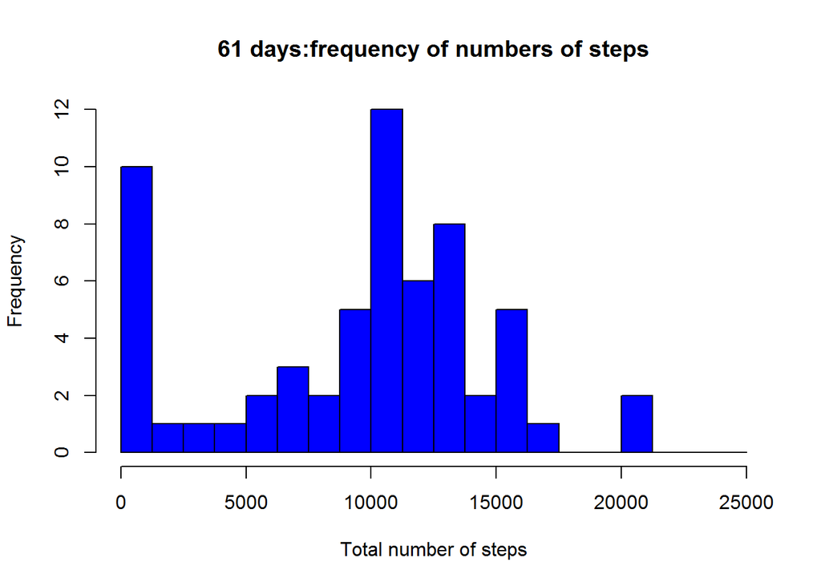

```r
hist(stepsPerDay$total,
     breaks=seq(from=0, to=25000, by=1250),
     col="blue",
     xlab="Total number of steps",
     ylab="Frequency",
     main="61 days:frequency of numbers of steps")
```

```r
meanSteps = mean(stepsPerDay$total)
medianSteps = median(stepsPerDay$total)
```

The mean number of steps per day is 9354.23.  
The median number of steps per days is 10395.00.

# What is the average daily activity pattern?

```r
stepsPerInterval = aggregate(dataset$steps, by = list(dataset$interval), FUN=mean, na.rm=TRUE)
names(stepsPerInterval) <- c("interval", "steps")
head(stepsPerInterval)
```

```
##   interval     steps
## 1        0 1.7169811
## 2        5 0.3396226
## 3       10 0.1320755
## 4       15 0.1509434
## 5       20 0.0754717
## 6       25 2.0943396
```

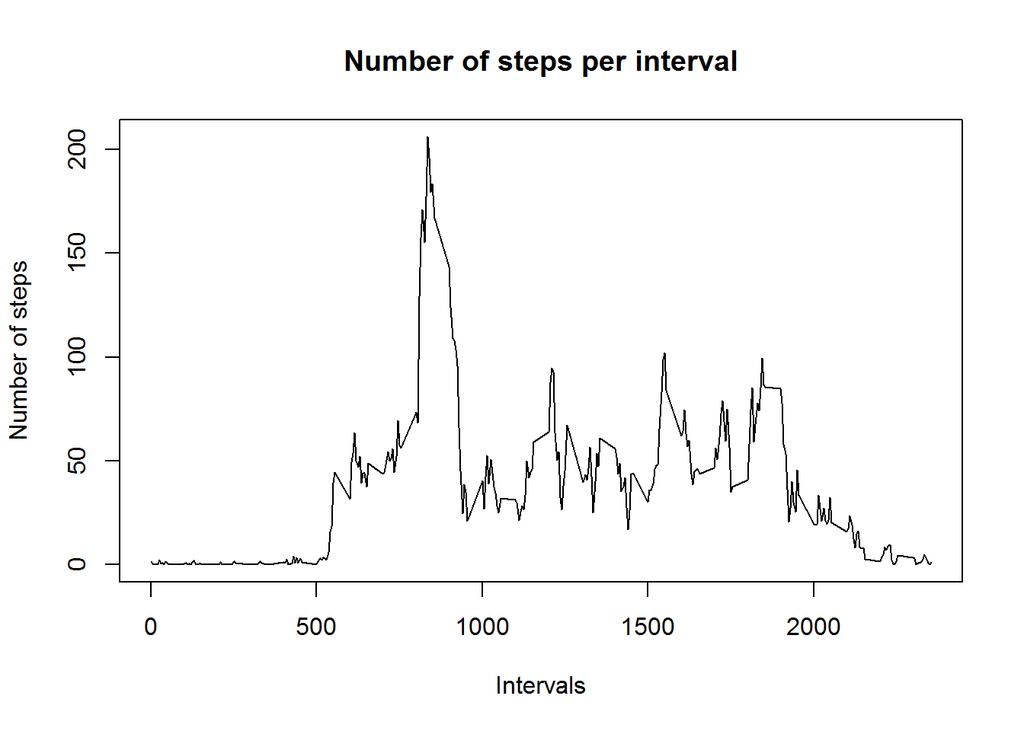

```r
plot(stepsPerInterval$interval,stepsPerInterval$steps,type = "l", col="black",  xlab="Intervals", ylab="Number of steps", main="Number of steps per interval")
```

```r
maxSteps = round(max(stepsPerInterval$steps),0)
mostActiveInterval <- stepsPerInterval[stepsPerInterval$steps==max(stepsPerInterval$steps),1]
```

Averagely this subject is most active around interval number 835. He or she takes on average 206 steps during that interval.

# Imputing missing values

## how many missing values are there?

- Find out the missing values by applying is.na to the steps-field in the dataframe
- if there is a missing value it will return TRUE – which counts as 1
- if not it will return FALSE – which counts as 0
- add them up and you will have the total of the missing values

```r
NA_count <- sum(is.na(dataset$steps))
```

There are 2304 missing values in the steps-field of the dataset.

## replace them by the mean of the interval of the missing value

- an NA in interval 5 on particular day will be replaced by the mean of interval 5 in general
- therefore:
- find the positions that have an NA in steps: posNA
- create a new dataset to preserve the original set: nwdataset
- and replace the NA’s on posNA with mean values from the stepPerInterval-df
- give an overview of nwdataset with str and head

```r
posNA <- which(is.na(dataset$steps))
nwdataset <- dataset
for (i in 1:length(posNA)){
        nwdataset[posNA[i],1] <- stepsPerInterval[stepsPerInterval$interval ==                   dataset[posNA[i],3],2]
}
str(nwdataset)
```

```
## 'data.frame':    17568 obs. of  3 variables:
##  $ steps   : num  1.717 0.3396 0.1321 0.1509 0.0755 ...
##  $ date    : Date, format: "2012-10-01" "2012-10-01" ...
##  $ interval: int  0 5 10 15 20 25 30 35 40 45 ...
```

```r
head(nwdataset)
```

```
##       steps       date interval
## 1 1.7169811 2012-10-01        0
## 2 0.3396226 2012-10-01        5
## 3 0.1320755 2012-10-01       10
## 4 0.1509434 2012-10-01       15
## 5 0.0754717 2012-10-01       20
## 6 2.0943396 2012-10-01       25
```

## make a histogram of the total number of steps in nwdataset

- make a histogram with the new values
- calculate and report the mean and median total number of steps taken per day
- make sure the difference between the first and second calculation is obvious
- interpret the difference

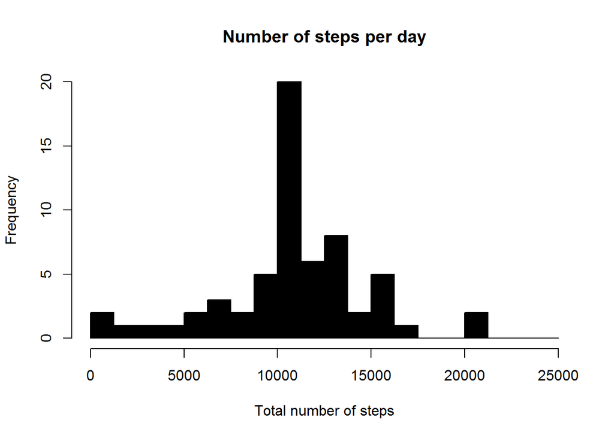

```r
nwStepsPerDay = aggregate(nwdataset$steps, by = list(nwdataset$date), FUN=sum)
names(nwStepsPerDay) <- c("date", "total")
hist(nwStepsPerDay$total, breaks=seq(from=0, to=25000, by=1250), col="black",     xlab="Total number of steps", ylab="Frequency", main="Number of steps per day")
```

```r
nwMeanSteps = mean(nwStepsPerDay$total)
nwMedianSteps = median(nwStepsPerDay$total)
```